# Data Camp / Intro to Time Series Analysis - Chapter 5

Initialize and load the data

Chapter 5 of [Data Camp - Intro to Time Series Analsys](https://www.datacamp.com/courses/introduction-to-time-series-analysis)

## Simple Moving Average Model

*Today = Mean + noise + Slope * (Yesterday’s Noise)*

$Y_t = \mu + \epsilon_t + \Theta\epsilon_{t-1}$

Where $\epsilon_t$ is mean 0 WN.

3 parms:

- $\mu$
- Slope $\Theta$
- WN Variance

If slope $\Theta$ is 0 then it’s simply a WN model. Otherwise $Y_t$ depends on both $\epsilon_t$ and $\epsilon_{t-1}$ and the process ${Y_t}$ is autocorrelated.

Large values of $\Theta$ lead to greater autocorrelation.

Netative values result in oscillatory ts.

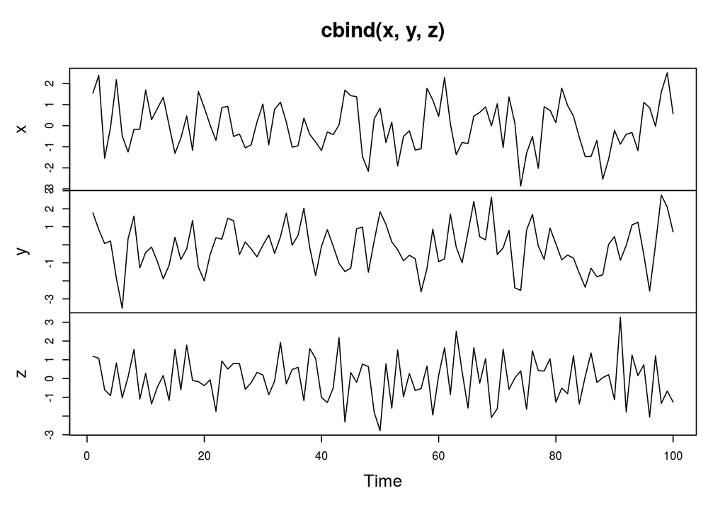

```r
x <- arima.sim(model = list(ma=0.5), n = 100)

y <- arima.sim(model=list(ma=0.9), n=100)

z <- arima.sim(model=list(ma=(-0.5)), n=100)

plot.ts(cbind(x, y, z))
```

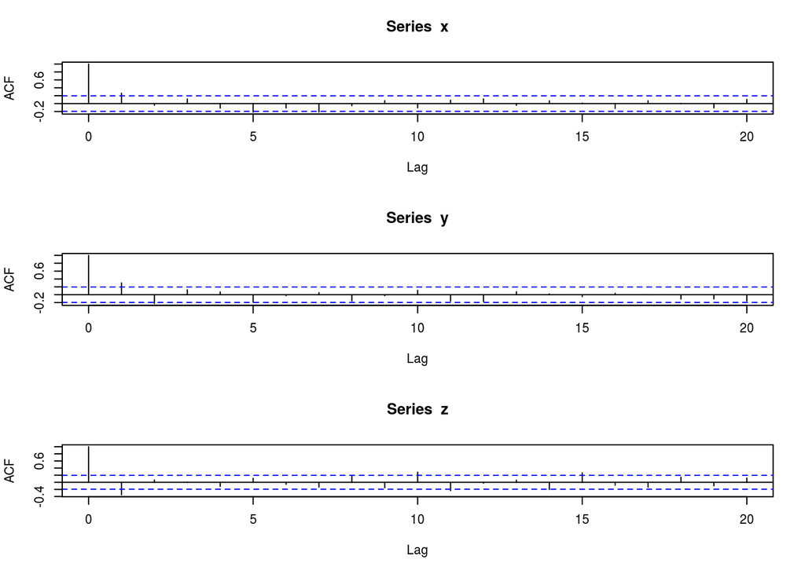

```r
par(mfrow=c(3,1))
acf(x)
acf(y)
acf(z)
```

### MA Model Esitmation and Forecasting

Apply process to inflation from Ecdat package

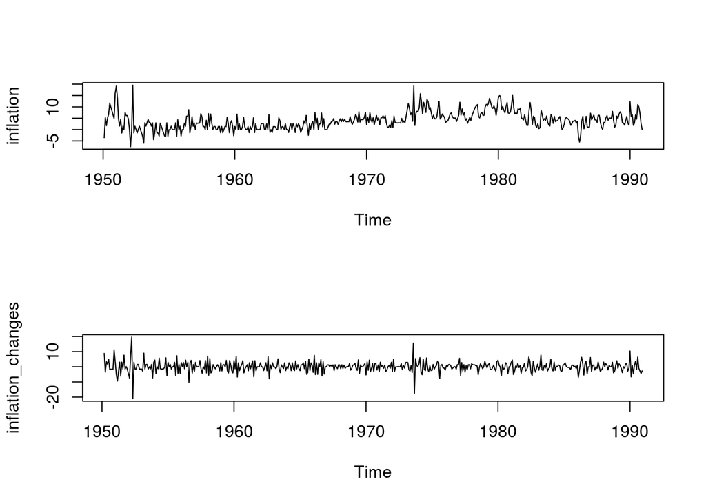

```r
data(Mishkin, package='Ecdat')

inflation <- as.ts(Mishkin[,1])
inflation_changes <- diff(inflation)
par(mfrow=c(2,1))
ts.plot(inflation)
ts.plot(inflation_changes)
```

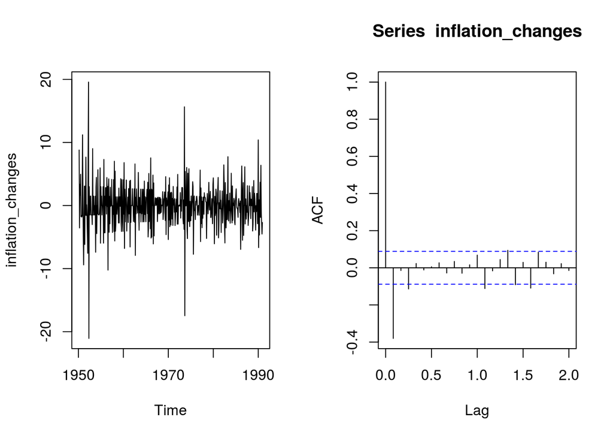

```r
par(mfrow=c(1,2))
ts.plot(inflation_changes)
acf(inflation_changes,lag.max=24)
```

The ACF shows a strong negative correlation at lag=1 and the remaining fluctuation near 0.

```r
MA_inflation_changes = arima(inflation_changes, order=c(0, 0, 1))
print(MA_inflation_changes)
```

```
##
## Call:
## arima(x = inflation_changes, order = c(0, 0, 1))
##
## Coefficients:
##           ma1  intercept
##       -0.7932     0.0010
## s.e.   0.0355     0.0281
##
## sigma^2 estimated as 8.882:  log likelihood = -1230.85,  aic = 2467.7
```

### Plot the fitted values

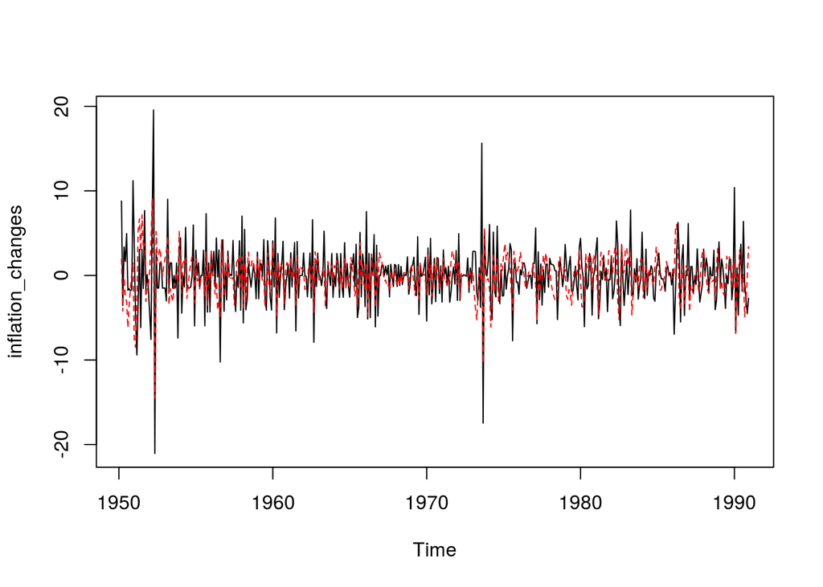

```r
ts.plot(inflation_changes)
MA_inflation_changes_fitted = inflation_changes - residuals(MA_inflation_changes)
points(MA_inflation_changes_fitted, type='l', col='red', lty=2)
```

### Use `predict()` to see the future!

```r
predict(MA_inflation_changes)
```

```
## $pred
##           Jan
## 1991 4.831632
##
## $se
##           Jan
## 1991 2.980203
```

```r
predict(MA_inflation_changes, n.ahead = 6)
```

```
## $pred
##              Jan         Feb         Mar         Apr         May
## 1991 4.831631501 0.001049346 0.001049346 0.001049346 0.001049346
##              Jun
## 1991 0.001049346
##
## $se
##           Jan      Feb      Mar      Apr      May      Jun
## 1991 2.980203 3.803826 3.803826 3.803826 3.803826 3.803826
```

# fit to Nile data

```r
MA <- arima(Nile, order = c(0, 0, 1))
print(MA)
```

```
##
## Call:
## arima(x = Nile, order = c(0, 0, 1))
##
## Coefficients:
##          ma1  intercept
##       0.3783   919.2433
## s.e.  0.0791    20.9685
##
## sigma^2 estimated as 23272:  log likelihood = -644.72,  aic = 1295.44
```

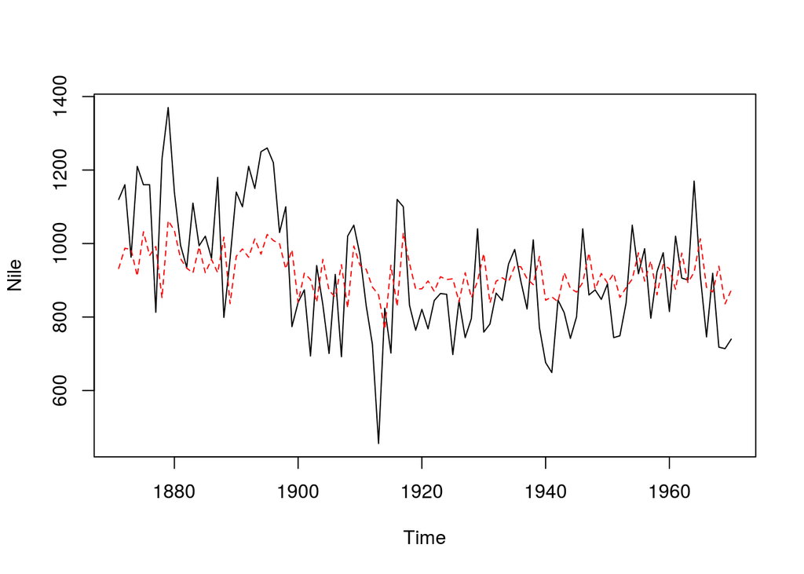

```r
ts.plot(Nile)
MA_fit <- Nile - resid(MA)
points(MA_fit, type = "l", col = 2, lty = 2)
```

### MA and AR process

MA and AR models are similar except that an MA model has autocorrelation at 1 lag and an AR model has autocorrelation at many lags.

**I**nformation **C**riteria are a way to check the goodness of fit. Generally, lower values are better. There are 2 available `AIC()` **Akaike Information Criterion** and `BIC()` **Bayesian Information Criterion**.